# Portfolio - 02

Author

Tyler Moore

Published

April 17, 2026

# Introduction

The goals of this Monte Carlo study are to evaluate the impact of sample size on the point estimators and interval estimators for Binomial distributions. We accomplish this by examining the differences in mean square error (MSE) for our point estimator and performing coverage evaluation of confidence intervals (CI). We will also evaluate the difference between using the Frequentest and Bayesian methods of calculating MSE and CI.

# Methods

Our study was conducted by evaluating the binomial distribution using the rbinom() function in r. We conducted the random draws for every combination of the following values for draw size (n) and probability (p):

- n = 5, 10, 15, 20, 25, 30
- p = 0.1, 0.2, 0.3, 0.4, 0.5, 0.6, 0.7, 0.8, 0.9

We replicated each draw 10^{5} times. We then evaluated two statistics using the Frequentist (MLE) and the Bayesian methods. The statistics evaluated were:

• Mean Square Error • Confidence Interval Coverage ($\alpha$ = 0.05)

# Results

## Mean Square Error

In the first figure we have the mean squared errors of our draws for each combination of n and p.

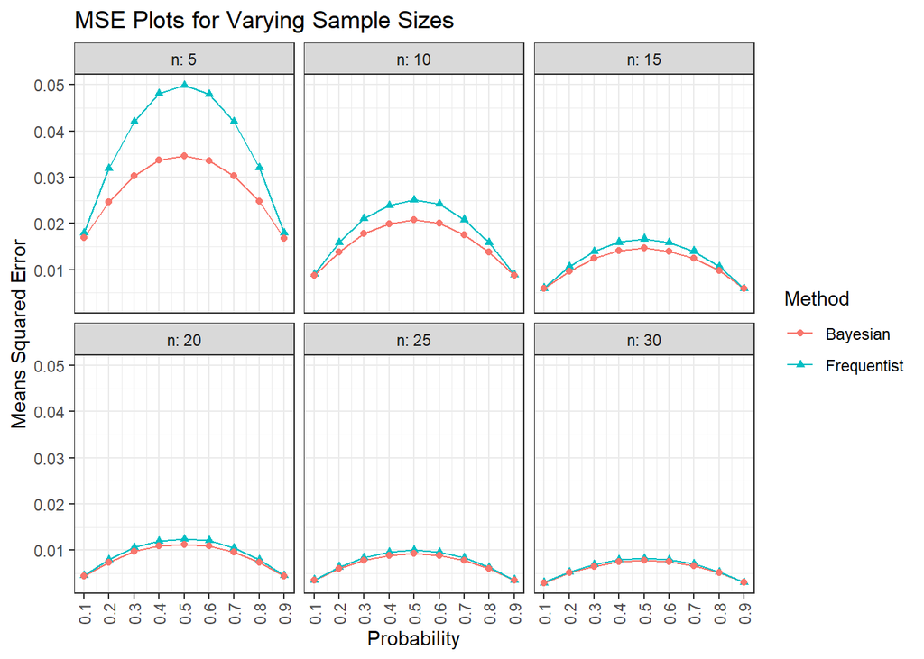

Using the Bayesian method of calculating $\hat{p}_{Bayes}$ leads to smaller MSE than using the Frequentist maximum likelihood estimator for $\hat{p}_{MLE}$. What we also notice from the figure is that as sample size n increases the difference between the MSE of the two methods is greatly reduced, such that with sample size n=30 the two MSE’s are nearly the same. We can conclude that for small sample sizes $\text{MSE}(\hat{p})$ is larger using Frequentist methods than Bayesian methods. We also can see that for probabilities near 0.5 the MSE are larger than the more extreme values of p, such as p < 0.3 and p > 0.7 no matter the sample size, as evidenced in the parabolic shape in figure 1.

## Interval Coverage

Next we evaluated the probability the confidence interval will contain the true probability (p). We accomplished this by evaluating the confidence interval of all replicated samples and calculating the proportion of intervals which contained the true probability (p) with the interval. The results of that analysis are shown in the second figure.

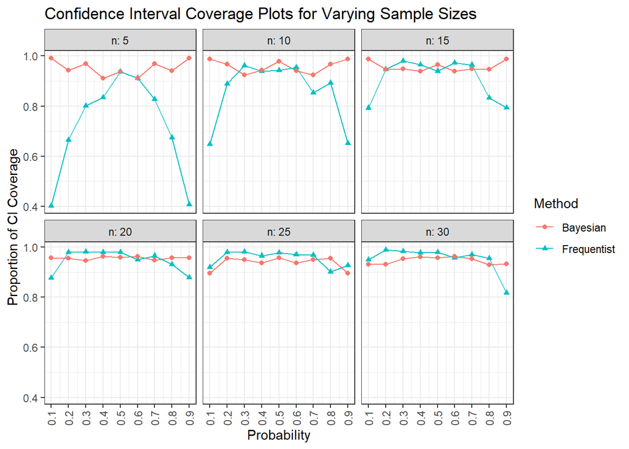

From the figure we can see that for the Bayesian intervals the proportion of coverage is above 0.9 for nearly all combinations of sample size and probability. However, using the Frequentist method resulted in a parabolic distribution with approximately 40% coverage for sample size 5 at p = 0.1 and p = 0.9. That same parabolic shape is seen for nearly all the sample sizes, though as n increases we can see that the proportion of coverage increases as well, such that when n reaches 25 the proportion of coverage is nearly identical to the Bayesian intervals.

# Discussion